# Lab 6 Wakerley

Author

Kyle Wakerley

## Load In Data

```r
library(dplyr)
library(ggplot2)
#install.packages("tidytext")
library(tidytext)
mt = read.csv("C:/Users/kylew/Downloads/mtsamples.csv")
```

## Count Specialty

```r
mt %>% count(medical_specialty) %>% arrange(desc(n))
```

```
                medical_specialty    n
1                         Surgery 1103
2      Consult - History and Phy.  516
3      Cardiovascular / Pulmonary  372
4                      Orthopedic  355
5                       Radiology  273
6                General Medicine  259
7                Gastroenterology  230
8                       Neurology  223
9   SOAP / Chart / Progress Notes  166
10        Obstetrics / Gynecology  160
11                        Urology  158
12              Discharge Summary  108
13           ENT - Otolaryngology   98
14                   Neurosurgery   94
```

[output cut: 26 more lines]

There are 40 categories of “medical_specialty”. Surgery is a very broad specialty and likely has links to most other specialties. Neurology and Neurosurgery are also related. Nephrology is also related to other endocrine functions such as Urology.

## Question 2: Tokenizing

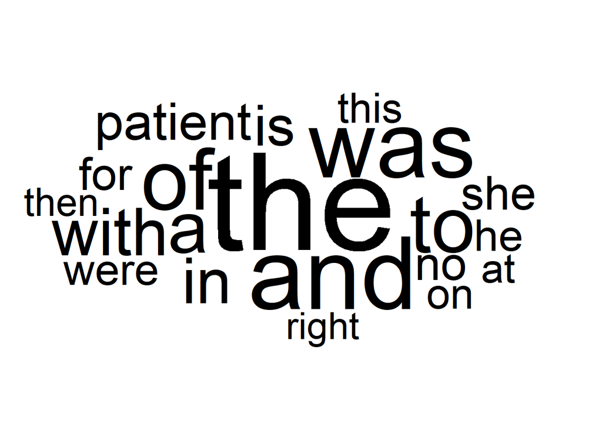

```r
mt_top_20 = mt %>% unnest_tokens(token, transcription) %>% count(token) %>% top_n(20,n) %>% arrange(desc(n))

#install.packages("ggwordcloud")
library(ggwordcloud)
ggplot(mt_top_20, aes(label = token, size = n)) +
  geom_text_wordcloud() +
  scale_size_area(max_size = 40) +
  theme_minimal()
```

We see most of the top 20 words are common stop words (and, the, was, of, with). Another expected results is that the word patient is in the top 20. Due to the number of stop words, we cannot gain much from this result.

## Removing Stop Words

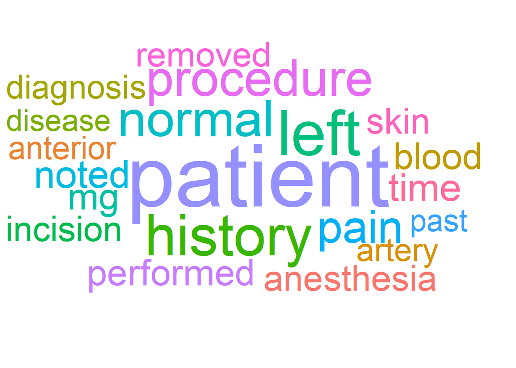

```r
library(stringr)
mt_nostop = mt %>% unnest_tokens(token, transcription) %>% anti_join(stop_words, by = c("token" = "word")) %>% filter(!str_detect(token, "[[:digit:]]"))

mt_nostop_c = mt_nostop %>% count(token) %>% top_n(20,n) %>% arrange(desc(n))


ggplot(mt_nostop_c, aes(label = token, size = n, color = token)) +
  geom_text_wordcloud() +
  scale_size_area(max_size = 30) +
  theme_minimal()
```

Now that we have removed stop words, we can see that patient is the top word (which makes sense because it appeared in the top 20 words even with stop words included). Now though, we can see that procedure, history, left, and pain are common words in these data. There are also words related to surgery such as anesthesia, performed, and incision. This tells us that a lot of people came to the doctor in pain, and underwent a procedure.

```r
library(patchwork)
mt_bigram = mt %>% unnest_ngrams(ngram, transcription, n = 2) %>% count(ngram) %>% top_n(20,n) %>% arrange(desc(n))
mt_bigram %>% head()
```

```
        ngram     n
1 the patient 20307
2      of the 19062
3      in the 12790
4      to the 12374
5    was then  6956
6     and the  6350
```

```r
mt_trigram = mt %>% unnest_ngrams(ngram, transcription, n = 3) %>% count(ngram) %>% top_n(20,n) %>% arrange(desc(n))
mt_trigram %>% head()
```

```
               ngram    n
1    the patient was 6104
2     the patient is 3075
3         as well as 2243
4        there is no 1678
5 the operating room 1532
6       patient is a 1491
```

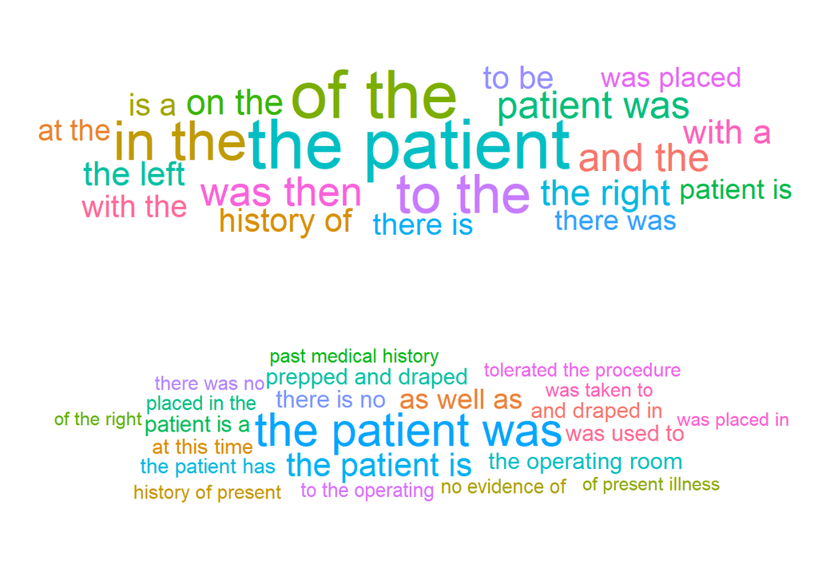

```r
bigram_plot = ggplot(mt_bigram, aes(label = ngram, size = n, color = ngram)) +
  geom_text_wordcloud() +
  scale_size_area(max_size = 15) +
  theme_minimal()

trigram_plot = ggplot(mt_trigram, aes(label = ngram, size = n, color = ngram)) +
  geom_text_wordcloud() +
  scale_size_area(max_size = 10) +
  theme_minimal()

combined_plot = bigram_plot / trigram_plot

combined_plot
```

Looking at the bigrams first, we see common two word parings such as “of the”, “to the”, and “at the”. The most common pairing was “the patient”. This makes sense because we are working in the hospital setting.

## Question 5, Looking at Words before and after patient

```r
library(stringr)
mt %>% unnest_ngrams(ngram, transcription, n = 2) %>%
  select(ngram) %>%
  filter(str_detect(ngram, "\\bpatient\\b")) %>%
  unnest_tokens(token, ngram) %>%
  count(token) %>%
  arrange(desc(n)) %>%
  filter(token != "patient" & token != "patient's") %>% head()
```

```
      token     n
1       the 22512
2       was  6296
3        is  3336
4       has  1417
5 tolerated   994
6       had   890
```

Looking at words that come before and after patient, we see that words like “the”, “was”, “is”, “has”, “tolerated”, and “had” showed up frequently. “The” had by far the most number of instances, at 22512 (these were probably all before the word patient). Tolerated is likely a common word because it describes how the patient did during and after the procedure or treatment.

## Common Words by Specialty

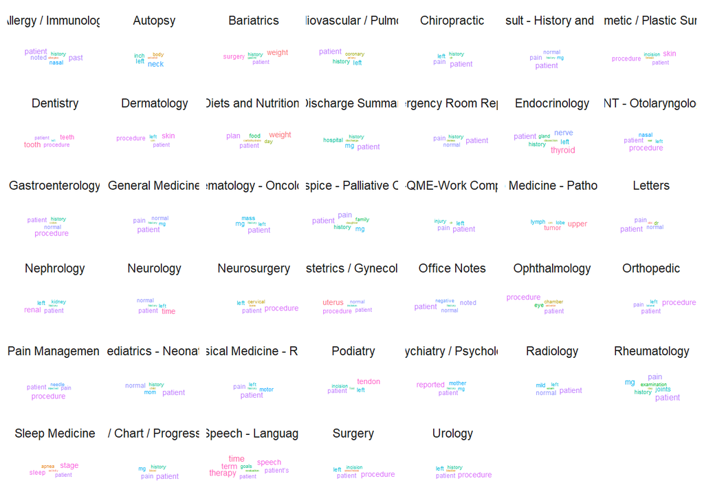

```r
mt_spec = mt_nostop %>% group_by(medical_specialty) %>% count(token) %>% top_n(5, n) %>% mutate(rank = rank(token))

   ggplot(data = mt_spec, aes(label = token, size = rank, color = token)) +
   geom_text_wordcloud() +
   scale_size_area(max_size = 2.3) +
   theme_minimal() + facet_wrap(~medical_specialty)
```

Looking at each specialty, we see words that one would associate with the area. For example, Allergy has “nasal” and “allergies”, along with “past” and “history”. A lot of their work likely revolves around asking about previous allergy history. Neurosurgery includes the word cervical, which also checks out, since spinal work is closely related to brain and neural function.

## Question 7: Specialized Words

Which words are found in a specific specialty, but not found in any other specialty?

```r
mt_spec_15 = mt_nostop %>% group_by(medical_specialty) %>% count(token) %>% top_n(15, n)

unique_tokens = mt_spec_15 %>%
  ungroup() %>%
  distinct(token, .keep_all = TRUE) %>% count(medical_specialty, sort = T)

unique_tokens %>% head()
```

```
# A tibble: 6 × 2
  medical_specialty               n
  <chr>                       <int>
1 " Allergy / Immunology"        19
2 " Autopsy"                     15
3 " Bariatrics"                  14
4 " Speech - Language"           12
5 " Diets and Nutritions"        11
6 " Lab Medicine - Pathology"    11
```

```r
unique_tokens %>% tail()
```

```
# A tibble: 6 × 2
  medical_specialty             n
  <chr>                     <int>
1 " Urology"                    3
2 " IME-QME-Work Comp etc."     2
3 " Orthopedic"                 2
4 " Emergency Room Reports"     1
5 " General Medicine"           1
6 " Hematology - Oncology"      1
```